# Praca domowa 2

Mateusz Stasiak

## Dane

Dane wykorzystane w Pracy domowej 2 opisują wycenę nieruchmości. Każda obserwacja jest pewną nieruchmością, która posiada informacje takie jak powierzchnia, liczba pokoi, liczba łazienek i wiele więcj. Opis wszystkich kolumn w pliku `README.md`.

## Zadanie 1

Jak wygląda rozkład ceny nieruchomości w poszczególnych kodach pocztowych na przestrzeni lat? Rozważamy kody pocztowe, które mają więcej niż 280 posiadłości.

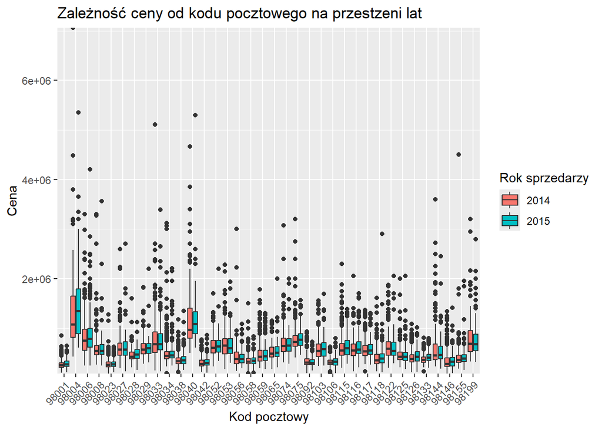

```r
# Tu umieść kod do wygenerowania odpowiedzi do zadania.

df_1<-df %>%
    group_by(zipcode) %>%
    summarise(sum=n()) %>%
    filter(sum>280)

df_1<-df_1 %>%
    inner_join(df) %>%
    select(-sum) %>%
    mutate(rok_sprzedarzy=substr(date,1,4)) %>%
   # group_by(zipcode,rok_sprzedarzy) %>%
   # summarise(srednia_cena=mean(price)) %>%
    mutate(zipcode=as.character(zipcode))


#View(df_1)
#x<-max(df_1$srednia_cena)
df_1 %>% ggplot(aes(x=zipcode,y=price,fill=rok_sprzedarzy))+
    geom_boxplot(position=position_dodge(width=0.92)) +
    scale_x_discrete(guide=guide_axis(n.dodge=1,angle=45))+
    labs(x="Kod pocztowy",y="Cena",fill="Rok sprzedarzy",
        title ="Zależność ceny od kodu pocztowego na przestzeni lat")+
    #ylim(0,x)
    scale_y_continuous(expand=c(0,0))
```

**Komentarz:** Rozkład cen nieruchomości w analizowanych kodach pocztowych pokazuje duże zróżnicowanie cenowe w zależności od lokalizacji. Kody pocztowe takie jak 98004 charakteryzują się najwyższymi cenami i dużym rozrzutem, co może wskazywać na prestiżowe nieruchomości lub zróżnicowany rynek w tej lokalizacji. Widzimy też że w wiekszośći kodów pocztowcyh rozklad cen w roku 2014 i 2015 nie specjalnie się rózni, z kilkoma wyjątkami, w których też nie widać żadnego trendu, gdyż w niektórych ceny z roku na rok poszly do góry a w innych w dół.

## Zadanie 2

Czy jest różnica w rozkładzie ceny nierchomości od powierzchni mieszkalnej uwzględniając podział na nieruchomości z piwnicą i bez?

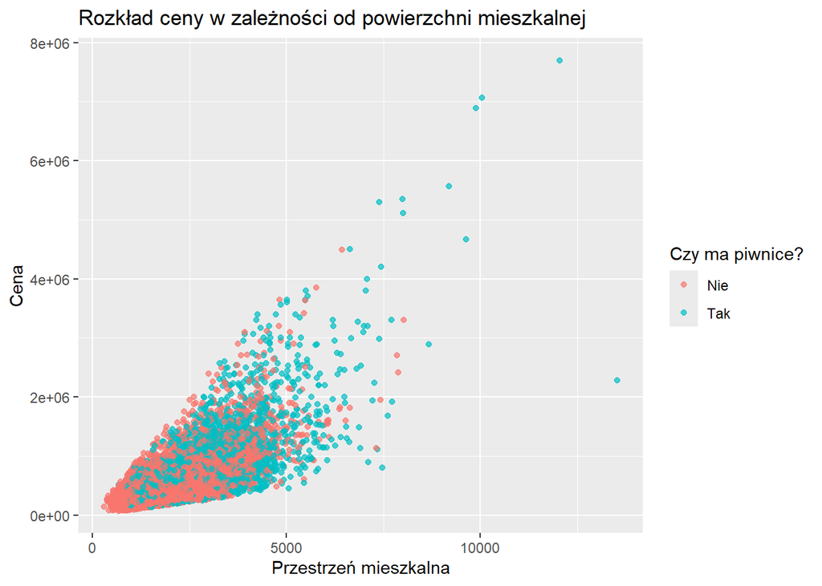

```r
# Tu umieść kod do wygenerowania odpowiedzi do zadania.

df_2<-df %>%
    mutate(piwnica=ifelse(sqft_basement==0,"Nie","Tak")
           )

df_2 %>% ggplot(aes(y=price,x=sqft_living,color=piwnica))+
    geom_point(alpha = 0.7)+
    labs(x="Przestrzeń mieszkalna",y="Cena",color="Czy ma piwnice?",
         title="Rozkład ceny w zależności od powierzchni mieszkalnej")
```

**Komentarz:** Po pierwsze widzimy że wśród mieszkań o niskiej przestrzeni mieszkalnej praktycznie nie występują piwnice, jest to raczej oczywisty wniosek. Z tego powodu sprobojemy wyciagnac wnioski patrzac na mieszkania o wyzszym metrarzu. Dla takich mieszkań widziemy, że przeważnie dla danej powierzchni mieszkalnej, mieszkania posiadające piwnice są droższe niż te ktore jej nie posiadają.

## Zadanie 3

Jaka jest zależność pomiędzy jakością wykończenia nieruchomości a liczbą pięter?

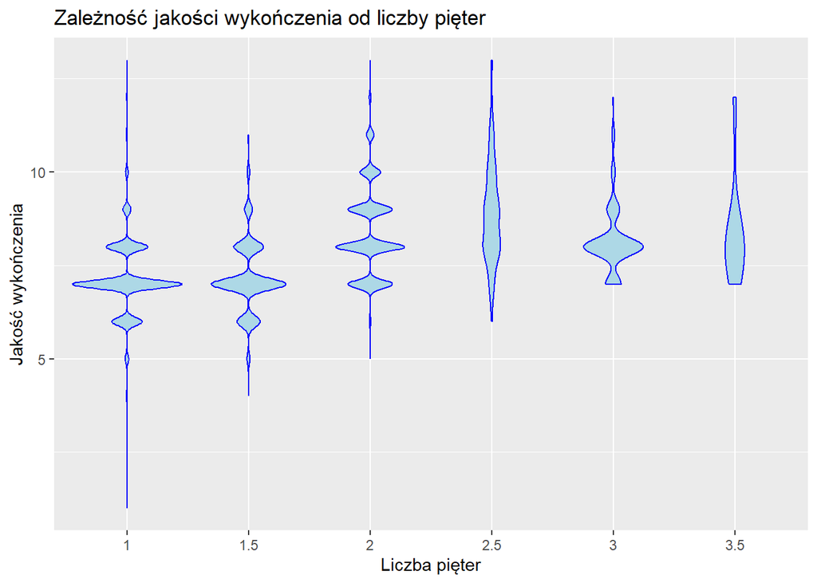

```r
# Tu umieść kod do wygenerowania odpowiedzi do zadania.


df %>%
    ggplot(aes(x=as.factor(floors),y=grade))+
    geom_violin(fill = "lightblue", color = "blue")+
    labs(x="Liczba pięter",y="Jakość wykończenia",
         title="Zależność jakości wykończenia od liczby pięter")
```

**Komentarz:** Widzimy ze dla mieszkań od 1 do 2 pięter mamy duże zróżńicowanie jakości wykończenia. Mamy tez w tym przedziale najwiecej mieszkańo niskim poziomie wykończenia. Można zauważyć że mieszkania mające ponad 2 piętra mają przeważńie wyzszy standard oraz mniejsze wachania w jakośći.

## Zadanie 4

Jaka jest zależność między powierzchnią mieszkalną nieruchomości a powierzchnią gruntu w podziale na liczbę sypialni?

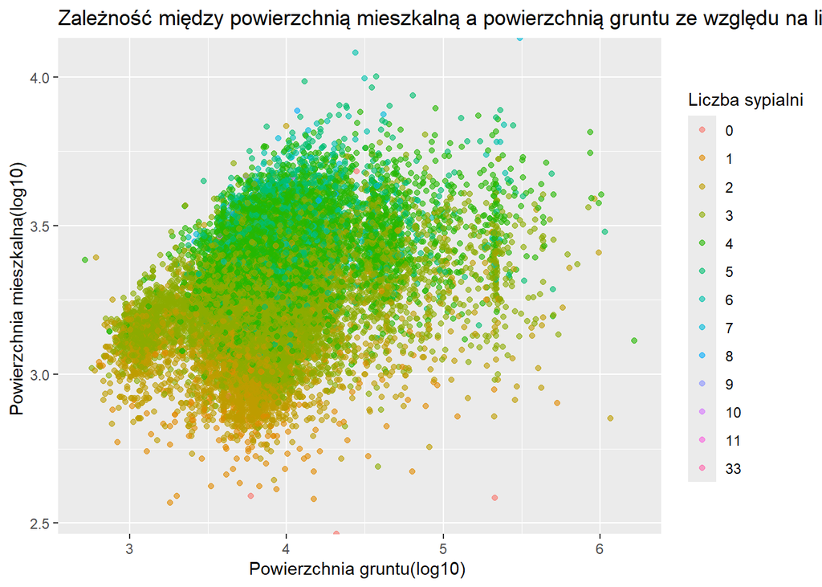

```r
# Tu umieść kod do wygenerowania odpowiedzi do zadania.
#print(unique(df$bedrooms))


df_4<-df %>%
    mutate(sqft_lot=log10(sqft_lot),
           sqft_living=log10(sqft_living))
    #bierzemy logarytmy zeby lepiej bylo widac

df_4 %>% ggplot(aes(x = sqft_lot, y = sqft_living, color = as.factor(bedrooms))) +
        geom_point(alpha = 0.6) +
        scale_y_continuous(expand = c(0, 0)) +
        labs(title = "Zależność między powierzchnią mieszkalną a powierzchnią gruntu ze względu na liczbę sypialni ",
            x = "Powierzchnia gruntu(log10) ",
            y = "Powierzchnia mieszkalna(log10) ",
            color = "Liczba sypialni")
```

## Zadanie 5

Rozważmy tylko nieruchomości, które miały remont. W której dekadzie było najwięcej przeprowadzonych remontów? Czy w poszczególnych dekadach jest porównywalny procent nieruchmości dla każdej wartości miary jakości i wykończenia nieruchomości?

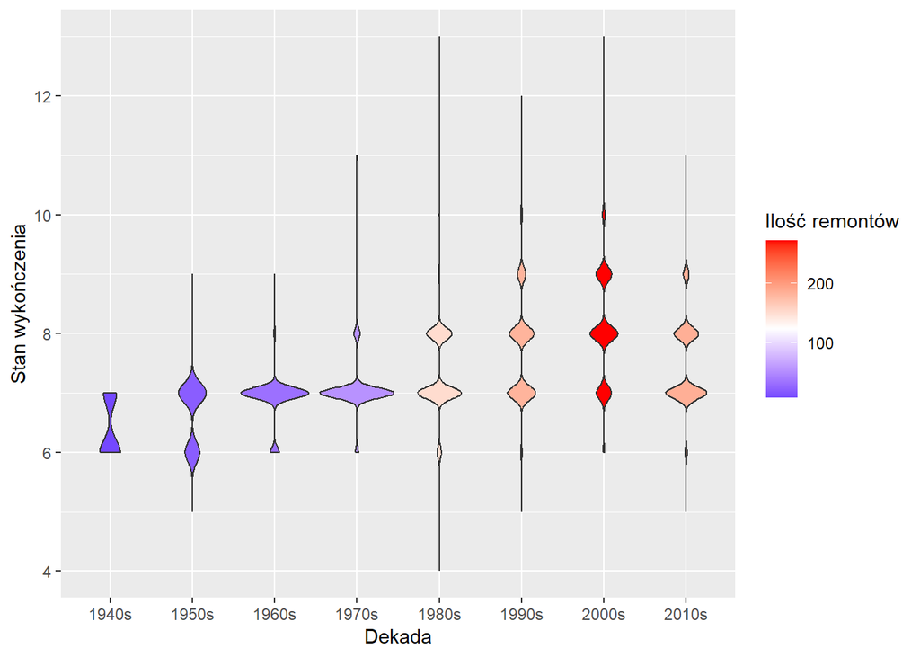

```r
# Tu umieść kod do wygenerowania odpowiedzi do zadania.

df_5<-df %>%
    filter(yr_renovated!=0) %>%
    mutate(dekada=paste(as.character((as.integer(yr_renovated/10))*10),"s",sep="")) %>%
    filter(dekada!="1930s") #Obcinam 1930s bo sa tam tylko 2 mieszkania i itak nie przydadza sie
                            #do wyciganiecia zadanych wnioskow

df_5_pom<-df_5 %>%
    group_by(dekada) %>%
    reframe(ilosc_remontow=n(),grade)

df_5 <- df_5 %>%
    inner_join(df_5_pom,relationship = "many-to-many")

#View(df_5)

#View(df_5)
df_5 %>%
    ggplot(aes(x=dekada,y=grade,fill=ilosc_remontow))+
    geom_violin()+
    scale_fill_gradient2(low = "blue", mid = "white", high = "red", midpoint = 125)+
    labs(y="Stan wykończenia",x="Dekada",fill="Ilość remontów")
```

**Komentarz:** Po pierwsze widzimy że dekadą w której odbyło się najwięcej remontów sa lata dwutysięczne. Ponadto widzimy ze w prawie każdej dekadzie jest najwięcej rozważancyh mieszkań o stanie wykończenia równym 7. Widzimy też że procenty nieruchmości dla każdej wartości miary różnią się na przestrzeni dekad. We wcześniejszych z nich widzimy że większość z nich ma stan wykończenia równy lub niższy od 7 natomiast z czasem widzimy tendencje wzrostową gdzie z każdym rokiem coraz wiekszą część mieszkań stanowią te o lepszej jakości. Sczytowym momentem tego tendu jest dekada 2000s, która jest jedyną gdzie najwięcej mieszkań ma grade równy 8 czyli wyższy od 7.

## Zadanie 6

Jak prezentuje się wartość minimalna, średnia i maksymalna ceny nieruchmości w podziele na rok budowy nieruchomości.

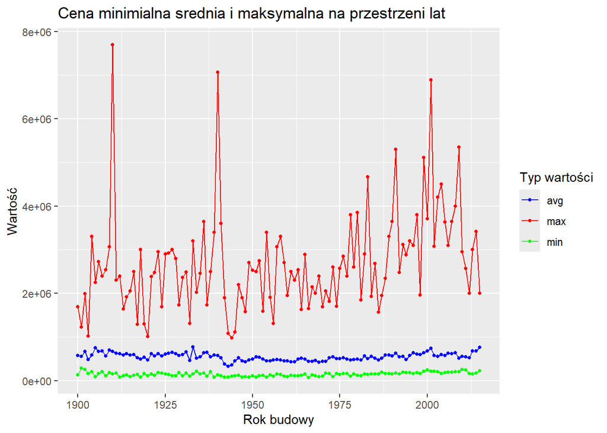

```r
# Tu umieść kod do wygenerowania odpowiedzi do zadania.

df_6<-df %>%
    group_by(yr_built) %>%
    summarise(
        min=min(price),
        avg=mean(price),
        max=max(price)
    ) %>%
    pivot_longer(cols=c(min,max,avg),
                 names_to="typ",values_to="wartosc")

#View(df_6)


df_6 %>%
    ggplot(aes(x=yr_built,y=wartosc,color=typ))+
    geom_point(size=1)+
    geom_line()+
    scale_color_manual(values = c("blue", "red", "green"))+
    labs(title = "Cena minimialna srednia i maksymalna na przestrzeni lat",
         x = "Rok budowy",
         y = "Wartość",
         color = "Typ wartości")
```